# A Model to Predict the Net Upvotes of a Reddit Post on r/UMD

Have you ever wanted to make a social media post go viral? In this project, I take you through the data science pipeline of obtaining Reddit data, processing the data, then training a model to predict the net number of upvotes a post will obtain on r/UMD. My goal for this project is to create a model that can provide a rough prediction of the number of upvotes a post might get that can be used by someone looking to create a popular post.

## First, start off by installing and imported the necessary modules

```python
# Install praw if not already installed. This is what we will be using to scrape Reddit
!pip install praw
```

```python
# Necessary imports
import praw # Reddit scraping
import datetime # Dealing with Unix-time vs. human time
import numpy as np # Standard data science import to deal with vector data
import pandas as pd # Contains useful spreadsheet-like datastructre called DataFrame
```

## Now it's time to start the webscraping

First off, you will need to open up a Reddit account if you don't have one already. Then, you'll want to follow the below tutorial for how to open up a Reddit app, obtain your client_id and client_secret, etc.

https://towardsdatascience.com/scraping-reddit-data-1c0af3040768

Below is the code for how to do this, but since the client_secret and username are personal, it's best not to release these online; so instead, I have already obtained an authenticated praw object in a pickle object, and I'll just load this pickle object in.

```
praw_reddit = praw.Reddit(client_id="",
                     client_secret="",
                     user_agent="",
                     username = "")
```

```python
import pickle

with open("praw_reddit.pkl", 'rb') as file:
    praw_reddit = pickle.load(file)
```

## Now, use your praw object to enter into the desired subreddit

```python
subreddit = praw_reddit.subreddit("UMD")
subreddit
```

```
Subreddit(display_name='UMD')
```

## Read in the most recent submissions— unfortunately, this maxes out at 1000 per Reddit's policy

```python
count = 0
array = []
for submission in subreddit.new(limit=1000):
    count += 1
    array.append(submission)
```

```python
count
```

```
994
```

## Now we have an array of reddit post objects called Submissions

Let's filter out the submissions that haven't had enough time to receive enough upvotes. I'll use a 24-hour threshold for this (i.e. as long as a post is 24-hours old, then we'll consider it matured enough that it has received the majority of its upvotes and is good data to train on. This assumption may very well be weak and in that case, we would need to use a greater threshold, perhaps of anywhere from 2 days to a week. However, for this purposes of this project, we will just make the assumption that 24-hours is fine.

```python
# Get current utc
date_time_yesterday = datetime.datetime.now() - datetime.timedelta(hours = 24)
```

```python
# Drop all submissions that are less than 24-hours old
older_submissions = []
for i in array:
    if i.created_utc <= float(date_time_yesterday.timestamp()):
        older_submissions.append(i)
```

```python
# this is the number of posts that have had 24-hours to accumulate3 upvotes
print(len(older_submissions))
```

```
941
```

## Now, we'll want to shuffle our Submissions so that when we print the resulting dataframe we get posts that are further apart in post datetime

This step is not necessary, but it's nice when looking at the printout of the DataFrame

```python
# Shuffle
import random
random.shuffle(older_submissions)
```

# Feature Extraction from Data

Now that we have our data, we are going to extract features from it. These are any descriptors about a reddit post that we might find useful to predict its success. For example, the length of the title, length of description, average word length, etc. might all be useful descriptions.

```python
# Get features

# Feature 1: Title Length
title_length = []
for submission in older_submissions:
    title_length.append(len(submission.title))

# Feature 2: Description Length
description_length = []
for submission in older_submissions:
    description_length.append(len(submission.selftext))

# Feature 3: Flair
flairs = []
for submission in older_submissions:
    flairs.append(submission.link_flair_text)

# Feature 4: is_video
is_video = []
for submission in older_submissions:
    is_video.append(submission.is_video)

# Feature 5: is_now_follow
is_no_follow = []
for submission in older_submissions:
    is_no_follow.append(submission.no_follow)


# Number of Upvotes * Upvote ratio (this is our predictor)
upvotes = []
for submission in older_submissions:
    upvotes.append(submission.upvote_ratio * submission.ups)

data = pd.concat([pd.Series(upvotes), pd.Series(title_length), pd.Series(description_length), pd.Series(flairs), pd.Series(is_video), pd.Series(is_no_follow)], axis=1)
data.columns = ["upvotes", "title_length", "description_length", "flair", "is_video", "is_no_follow"]
```

```python
data.head()
```

|  | upvotes | title_length | description_length | flair | is_video | is_no_follow |
| --- | --- | --- | --- | --- | --- | --- |
| 0 | 0.67 | 48 | 99 | Help | False | True |
| 1 | 67.20 | 19 | 0 | Discussion | False | False |
| 2 | 3.32 | 27 | 203 | Events | False | False |
| 3 | 2.00 | 31 | 347 | Housing | False | False |
| 4 | 8.00 | 49 | 127 | Housing | False | False |

```python
data.describe()
```

|  | upvotes | title_length | description_length |
| --- | --- | --- | --- |
| count | 941.000000 | 941.000000 | 941.000000 |
| mean | 26.558448 | 44.351753 | 214.302869 |
| std | 54.286871 | 34.733799 | 390.503062 |
| min | 0.000000 | 1.000000 | 0.000000 |
| 25% | 2.000000 | 21.000000 | 23.000000 |
| 50% | 4.800000 | 35.000000 | 139.000000 |
| 75% | 17.290000 | 57.000000 | 264.000000 |
| max | 398.970000 | 295.000000 | 8763.000000 |

# Training a perliminary classifier: decision trees with sklearn

```python
import sklearn
from sklearn import tree
```

```python
# Get each row of data
X = [data.iloc[i][1:len(data.iloc[0])].tolist() for i in range(len(data))]
y = [data.iloc[i][0].tolist() for i in range(len(data))]
```

### In the below code block, if we try to run clf.fit(X,y), we get the following error

```python
clf = tree.DecisionTreeRegressor()
# clf.fit(X, y) # This is the line that produces the below error
```

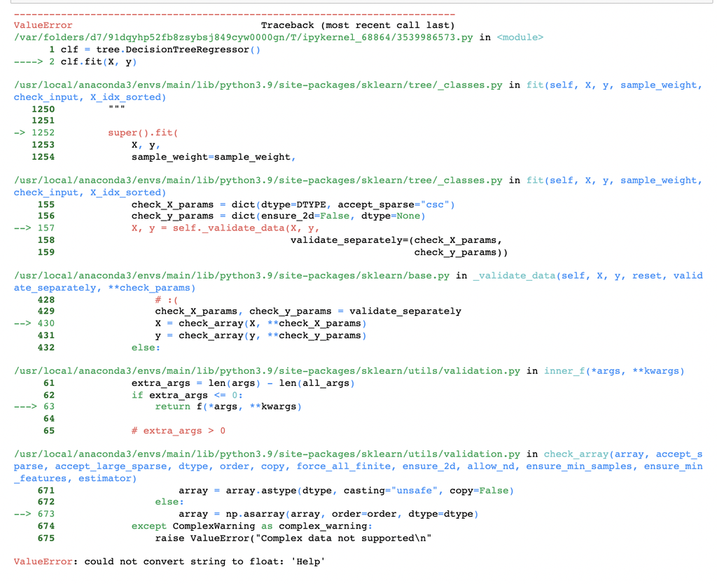

## We got an error!

It turns out that we cannot pass strings into the DecisionTreeRegressor classifier, so our post flair feature is not going to work here. One way to fix this would be to convert the flair to an integer. This means for each of the 9 flairs, we would have an integer (like 0-8). However, this would assume that the flair of value 8 is worth more than the flair of value 0— since flair is not ordinal, this is not true!

So, the best way to move forward from this is to have boolean variables instead (like we did with the is_video and is_non_user). We would have a boolean for each of the flairs:

1. is_academic
2. is_athletics
3. is_discussion
4. is_events
5. is_help
6. is_housing
7. is_news
8. is_admissions
9. is_meme

However: we need to be careful. Defining 9 "dummy variables" to represent a categorical variable with 9 categories is not wise. This would likely introduce multicollinearity into our data. Additionally, a ninth variable is redundant since we have booleans for all others, so if all others are false, then the ninth is obviously true since all these boolean variables are mutually exclusive events.

To read more about this, see this website: https://stattrek.com/multiple-regression/dummy-variables.aspx

```python
# Redefine features

# Feature 1: Title Length
title_length = []
for submission in older_submissions:
    title_length.append(len(submission.title))

# Feature 2: Description Length
description_length = []
for submission in older_submissions:
    description_length.append(len(submission.selftext))

# Feature 3: is_academic
is_academic = []
for submission in older_submissions:
    is_academic.append(submission.link_flair_text == "Academic")

# Feature 4: is_athletics
is_athletics = []
for submission in older_submissions:
    is_athletics.append(submission.link_flair_text == "Athletics")

# Feature 5: is_discussion
is_discussion = []
for submission in older_submissions:
    is_discussion.append(submission.link_flair_text == "Discussion")

# Feature 6: is_events
is_events = []
for submission in older_submissions:
    is_events.append(submission.link_flair_text == "Events")

# Feature 8: is_help
is_help = []
for submission in older_submissions:
    is_help.append(submission.link_flair_text == "Help")

# Feature 9: is_housing
is_housing = []
for submission in older_submissions:
    is_housing.append(submission.link_flair_text == "Housing")

# Feature 10: is_news
is_news = []
for submission in older_submissions:
    is_news.append(submission.link_flair_text == "News")

# Feature 11: is_admissions
is_admissions = []
for submission in older_submissions:
    is_admissions.append(submission.link_flair_text == "Admissions")

# Feature 12: is_video
is_video = []
for submission in older_submissions:
    is_video.append(submission.is_video)

# Feature 13: is_no_follow
is_no_follow = []
for submission in older_submissions:
    is_no_follow.append(submission.no_follow)


# Number of Upvotes * Upvote ratio (this is our predictor)
upvotes = []
for submission in older_submissions:
    upvotes.append(submission.upvote_ratio * submission.ups)

data = pd.concat([pd.Series(upvotes), pd.Series(title_length), pd.Series(description_length),
                  pd.Series(is_video),pd.Series(is_academic), pd.Series(is_athletics), pd.Series(is_discussion),
                  pd.Series(is_events), pd.Series(is_help), pd.Series(is_housing),pd.Series(is_news),
                  pd.Series(is_admissions), pd.Series(is_no_follow)], axis=1)

data.columns = ["upvotes", "title_length", "description_length", "is_video", "is_academic",
                "is_athletics", "is_discussion", "is_events", "is_help", "is_housing", "is_news", "is_admissions",
                "is_no_follow"]
```

```python
data
```

|  | upvotes | title_length | description_length | is_video | is_academic | is_athletics | is_discussion | is_events | is_help | is_housing | is_news | is_admissions | is_no_follow |
| --- | --- | --- | --- | --- | --- | --- | --- | --- | --- | --- | --- | --- | --- |
| 0 | 0.67 | 48 | 99 | False | False | False | False | False | True | False | False | False | True |
| 1 | 67.20 | 19 | 0 | False | False | False | True | False | False | False | False | False | False |
| 2 | 3.32 | 27 | 203 | False | False | False | False | True | False | False | False | False | False |
| 3 | 2.00 | 31 | 347 | False | False | False | False | False | False | True | False | False | False |
| 4 | 8.00 | 49 | 127 | False | False | False | False | False | False | True | False | False | False |
| ... | ... | ... | ... | ... | ... | ... | ... | ... | ... | ... | ... | ... | ... |
| 936 | 97.01 | 90 | 0 | False | False | False | False | False | False | False | True | False | False |
| 937 | 12.00 | 33 | 122 | False | False | False | True | False | False | False | False | False | False |
| 938 | 0.67 | 59 | 0 | False | False | False | True | False | False | False | False | False | True |
| 939 | 273.23 | 39 | 1403 | False | False | False | True | False | False | False | False | False | False |
| 940 | 63.70 | 44 | 1696 | False | False | False | True | False | False | False | False | False | False |

941 rows × 13 columns

## Retry fitting decision tree classifier

Now that we've separated the categorical variable flair into dummy variables, we can try retraining the decision tree regressor.

```python
# Get each row of data
X = [data.iloc[i][1:len(data.iloc[0])].tolist() for i in range(len(data))]
y = [data.iloc[i][0].tolist() for i in range(len(data))]
```

```python
clf = tree.DecisionTreeRegressor()
clf.fit(X, y)
```

```
DecisionTreeRegressor()
```

## Predicting a post

Before we get to actually testing the performance of our classifier, lets just use it to see what it will predict for a hypothetical post. Say we are a member of r/UMD and our post is academic. Our title is 100 characters long and our description is 500. Here is how this is encoded:

[100, 500, False, True, False, False, False, False, False, False, False, False]

So, let's predict.

```python
x = clf.predict([[100, 500, False, True, False, False, False, False, False, False, False, False]])[0]
print("The predicted value is {}".format(x))
```

```
The predicted value is 5.0
```

## Splitting data

In order to actually test our model, we will have to split the data into train and test data. Let's reserve 700 posts to train our model and the rest to test it.

```python
train_data = data.iloc[0:700]
test_data = data.iloc[700:len(data)]
```

```python
# Separate train data into x and y
X = [train_data.iloc[i][1:len(train_data.iloc[0])].tolist() for i in range(len(train_data))]
y = [train_data.iloc[i][0].tolist() for i in range(len(train_data))]
```

```python
clf = tree.DecisionTreeRegressor()
clf.fit(X, y)
```

```
DecisionTreeRegressor()
```

```python
# Separate test data into x and y
X = [test_data.iloc[i][1:len(test_data.iloc[0])].tolist() for i in range(len(test_data))]
y = [test_data.iloc[i][0].tolist() for i in range(len(test_data))]
```

## Print out the average error of our model per post

```python
sum((abs(clf.predict(X) - y)))/len(test_data)
```

```
37.137759336099556
```

```python
x = [(clf.predict(X)[i], y[i]) for i in range(len(y))]
for i in x:
    print("Prediction is {} and expected {}".format(i[0], i[1]))
```

```
Prediction is 3.0 and expected 2.0
Prediction is 1.5 and expected 8.2
Prediction is 1.1 and expected 8.0
Prediction is 5.28 and expected 0.6
Prediction is 3.0 and expected 3.36
Prediction is 1.1 and expected 0.0
Prediction is 8.19 and expected 57.660000000000004
Prediction is 66.24 and expected 1.5
Prediction is 2.13 and expected 2.0
Prediction is 109.89 and expected 2.0
Prediction is 11.16 and expected 14.79
Prediction is 0.0 and expected 0.0
Prediction is 18.48 and expected 3.0
Prediction is 1.0 and expected 1.0
Prediction is 8.19 and expected 90.24
Prediction is 0.67 and expected 0.67
Prediction is 89.03999999999999 and expected 98.0
Prediction is 7.0 and expected 2.0
Prediction is 2.43 and expected 327.69
Prediction is 72.27 and expected 22.0
Prediction is 194.04 and expected 48.96
Prediction is 136.0 and expected 23.200000000000003
Prediction is 0.0 and expected 108.64
Prediction is 2.0 and expected 2.16
Prediction is 119.56 and expected 2.43
Prediction is 6.84 and expected 3.0
Prediction is 2.0 and expected 2.0
Prediction is 11.57 and expected 3.9000000000000004
Prediction is 23.25 and expected 4.800000000000001
Prediction is 109.89 and expected 29.4
Prediction is 94.0 and expected 0.0
Prediction is 15.47 and expected 111.0
Prediction is 104.16000000000001 and expected 29.45
Prediction is 14.1 and expected 14.0
Prediction is 4.0 and expected 2.43
Prediction is 2.0 and expected 23.0
Prediction is 165.0 and expected 7.800000000000001
Prediction is 0.57 and expected 0.57
Prediction is 3.0 and expected 5.390000000000001
Prediction is 5.0 and expected 3.36
```

[output cut: 186 more lines]

```
Prediction is 0.0 and expected 2.4000000000000004
Prediction is 7.2 and expected 17.8
Prediction is 1.34 and expected 7.0
Prediction is 60.48 and expected 32.339999999999996
Prediction is 1.34 and expected 3.0
Prediction is 0.0 and expected 1.0
Prediction is 88.2 and expected 130.95
Prediction is 2.0 and expected 14.1
Prediction is 107.8 and expected 90.0
Prediction is 3.32 and expected 5.0
Prediction is 9.0 and expected 97.01
Prediction is 32.98 and expected 12.0
Prediction is 0.0 and expected 0.67
Prediction is 32.4 and expected 273.23
Prediction is 32.4 and expected 63.699999999999996
```

## Low accuracy

So, we've tested our model and it seems to work for some posts but is heavily off for others. What if we change our regressor to a classifier and instead of having numbers as output, we have intervals of reddit votes?

Let's try this.

### Change data to intervals

Of course, these intervals are entirely subjective, but perhaps they can help our model out and give us a firmer way of modeling accuracy

```python
intervals = ["<=3", "3-10", "10-50", ">50"]

def find_interval(num):
    if num <=3:
        return "<=3"
    elif num < 10:
        return "3-10"
    elif num < 50:
        return "10-50"
    else:
        return ">50"
```

```python
data['upvotes'] = data['upvotes'].apply(find_interval)
```

```python
data
```

|  | upvotes | title_length | description_length | is_video | is_academic | is_athletics | is_discussion | is_events | is_help | is_housing | is_news | is_admissions | is_no_follow |
| --- | --- | --- | --- | --- | --- | --- | --- | --- | --- | --- | --- | --- | --- |
| 0 | <=3 | 48 | 99 | False | False | False | False | False | True | False | False | False | True |
| 1 | >50 | 19 | 0 | False | False | False | True | False | False | False | False | False | False |
| 2 | 3-10 | 27 | 203 | False | False | False | False | True | False | False | False | False | False |
| 3 | <=3 | 31 | 347 | False | False | False | False | False | False | True | False | False | False |
| 4 | 3-10 | 49 | 127 | False | False | False | False | False | False | True | False | False | False |
| ... | ... | ... | ... | ... | ... | ... | ... | ... | ... | ... | ... | ... | ... |
| 936 | >50 | 90 | 0 | False | False | False | False | False | False | False | True | False | False |
| 937 | 10-50 | 33 | 122 | False | False | False | True | False | False | False | False | False | False |
| 938 | <=3 | 59 | 0 | False | False | False | True | False | False | False | False | False | True |
| 939 | >50 | 39 | 1403 | False | False | False | True | False | False | False | False | False | False |
| 940 | >50 | 44 | 1696 | False | False | False | True | False | False | False | False | False | False |

941 rows × 13 columns

## Retrain regressor as a classifier!

```python
# split data
train_data = data.iloc[0:700]
test_data = data.iloc[700:len(data)]
```

```python
# Separate train data into x and y
X_train = [train_data.iloc[i][1:len(train_data.iloc[0])].tolist() for i in range(len(train_data))]
y_train = [train_data.iloc[i][0] for i in range(len(train_data))]
```

```python
clf = tree.DecisionTreeClassifier()
clf.fit(X_train, y_train)
```

```
DecisionTreeClassifier()
```

```python
# Separate test data into x and y
X_test = [test_data.iloc[i][1:len(test_data.iloc[0])].tolist() for i in range(len(test_data))]
y_test = [test_data.iloc[i][0] for i in range(len(test_data))]
```

```python
errors = sum([1 if clf.predict([u])[0] != v else 0 for u,v in zip(X_test,y_test)])
errors
```

```
131
```

### Let's find the accuracy of our model on our test data

```python
accuracy = 1 - errors/len(test_data)
accuracy
```

```
0.4564315352697096
```

## Hyperparameter Tuning

So far, we've seen a pretty low test accuracy. So, let's try to tune some of the hyperparameters of the DecisionTreeClassifier model

```python
import matplotlib.pyplot as plt
```

### Tree Depth

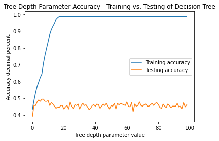

```python
best_accuracy = 0
best_depth = 0
train_accuracy = []
test_accuracy = []
x = [i for i in range(99)]

for i in range(1,100):
    clf = tree.DecisionTreeClassifier(max_depth=i)
    clf.fit(X_train, y_train)

    errors = sum([1 if clf.predict([u])[0] != v else 0 for u,v in zip(X_test,y_test)])
    accuracy = 1 - errors/len(test_data)
    if accuracy > best_accuracy:
        best_accuracy = accuracy
        best_depth = i

    errors = sum([1 if clf.predict([u])[0] != v else 0 for u,v in zip(X_train,y_train)])
    accuracy_train = 1 - errors/len(train_data)

    train_accuracy.append(accuracy_train)
    test_accuracy.append(accuracy)

fix, ax = plt.subplots()
ax.plot(x,train_accuracy)
ax.plot(x,test_accuracy)
ax.legend(["Training accuracy", "Testing accuracy"])
plt.title("Tree Depth Parameter Accuracy - Training vs. Testing of Decision Tree")
plt.xlabel("Tree depth parameter value")
plt.ylabel("Accuracy decimal percent")
plt.show()
```

```python
print("The best accuracy on test data was {}, which occurred when depth was set to {}".format(best_accuracy, best_depth))
```

```
The best accuracy on test data was 0.49377593360995853, which occurred when depth was set to 7
```

### Min samples for leaf node

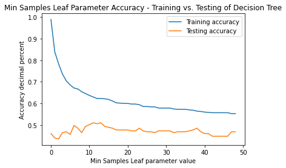

```python
best_accuracy = 0
best_min_samples = 0
train_accuracy = []
test_accuracy = []
x = [i for i in range(49)]

for i in range(1,50):
    clf = tree.DecisionTreeClassifier(min_samples_leaf=i)
    clf.fit(X_train, y_train)

    errors = sum([1 if clf.predict([u])[0] != v else 0 for u,v in zip(X_test,y_test)])
    accuracy = 1 - errors/len(test_data)
    if accuracy > best_accuracy:
        best_accuracy = accuracy
        best_min_samples = i

    errors = sum([1 if clf.predict([u])[0] != v else 0 for u,v in zip(X_train,y_train)])
    accuracy_train = 1 - errors/len(train_data)

    train_accuracy.append(accuracy_train)
    test_accuracy.append(accuracy)

fix, ax = plt.subplots()
ax.plot(x,train_accuracy)
ax.plot(x,test_accuracy)
ax.legend(["Training accuracy", "Testing accuracy"])
plt.title("Min Samples Leaf Parameter Accuracy - Training vs. Testing of Decision Tree")
plt.xlabel("Min Samples Leaf parameter value")
plt.ylabel("Accuracy decimal percent")
plt.show()
```

```python
print("The best accuracy on test data was {}, which occurred when split was set to {}".format(best_accuracy, best_min_samples))
```

```
The best accuracy on test data was 0.5103734439834025, which occurred when split was set to 12
```

### Max leaf nodes

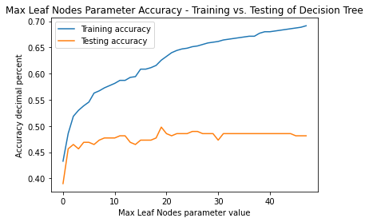

```python
best_accuracy = 0
best_leaf_node_max = 0
train_accuracy = []
test_accuracy = []
x = [i for i in range(48)]

for i in range(2,50):
    clf = tree.DecisionTreeClassifier(max_leaf_nodes=i)
    clf.fit(X_train, y_train)

    errors = sum([1 if clf.predict([u])[0] != v else 0 for u,v in zip(X_test,y_test)])
    accuracy = 1 - errors/len(test_data)
    if accuracy > best_accuracy:
        best_accuracy = accuracy
        best_leaf_node_max = i

    errors = sum([1 if clf.predict([u])[0] != v else 0 for u,v in zip(X_train,y_train)])
    accuracy_train = 1 - errors/len(train_data)

    train_accuracy.append(accuracy_train)
    test_accuracy.append(accuracy)

fix, ax = plt.subplots()
ax.plot(x,train_accuracy)
ax.plot(x,test_accuracy)
ax.legend(["Training accuracy", "Testing accuracy"])
plt.title("Max Leaf Nodes Parameter Accuracy - Training vs. Testing of Decision Tree")
plt.xlabel("Max Leaf Nodes parameter value")
plt.ylabel("Accuracy decimal percent")
plt.show()
```

```python
print("The best accuracy on test data was {}, which occurred when depth was set to {}".format(best_accuracy, best_leaf_node_max))
```

```
The best accuracy on test data was 0.4979253112033195, which occurred when depth was set to 21
```

### Min weight fraction leaf

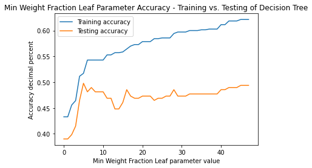

```python
best_accuracy = 0
best_min_weight = 0
train_accuracy = []
test_accuracy = []
x = [i for i in range(48)]

for i in range(2,50):
    clf = tree.DecisionTreeClassifier(min_weight_fraction_leaf=1/i)
    clf.fit(X_train, y_train)

    errors = sum([1 if clf.predict([u])[0] != v else 0 for u,v in zip(X_test,y_test)])
    accuracy = 1 - errors/len(test_data)
    if accuracy > best_accuracy:
        best_accuracy = accuracy
        best_min_weight = 1/i

    errors = sum([1 if clf.predict([u])[0] != v else 0 for u,v in zip(X_train,y_train)])
    accuracy_train = 1 - errors/len(train_data)

    train_accuracy.append(accuracy_train)
    test_accuracy.append(accuracy)

fix, ax = plt.subplots()
ax.plot(x,train_accuracy)
ax.plot(x,test_accuracy)
ax.legend(["Training accuracy", "Testing accuracy"])
plt.title("Min Weight Fraction Leaf Parameter Accuracy - Training vs. Testing of Decision Tree")
plt.xlabel("Min Weight Fraction Leaf parameter value")
plt.ylabel("Accuracy decimal percent")
plt.show()
```

```python
print("The best accuracy on test data was {}, which occurred when depth was set to {}".format(best_accuracy, best_min_weight))
```

```
The best accuracy on test data was 0.4979253112033195, which occurred when depth was set to 0.14285714285714285
```

## Final classifier after tuning

```python
clf = tree.DecisionTreeClassifier(min_samples_leaf=best_min_samples, max_depth=best_depth, min_weight_fraction_leaf=best_min_weight, max_leaf_nodes=best_leaf_node_max)
clf.fit(X_train, y_train)

errors = sum([1 if clf.predict([u])[0] != v else 0 for u,v in zip(X_test,y_test)])
accuracy = 1 - errors/len(test_data)
accuracy
```

```
0.4979253112033195
```

```python
final_decision_tree = clf
```

# Training a random forest

```python
from sklearn import ensemble

clf = ensemble.RandomForestClassifier(min_samples_leaf=best_min_samples, max_depth=best_depth, min_weight_fraction_leaf=best_min_weight, max_leaf_nodes=best_leaf_node_max)
clf.fit(X_train, y_train)

errors = sum([1 if clf.predict([u])[0] != v else 0 for u,v in zip(X_test,y_test)])
accuracy = 1 - errors/len(test_data)
accuracy
```

```
0.46058091286307057
```

## Hyperparameter Tuning

### Max Depth

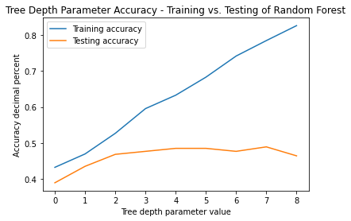

```python
best_accuracy = 0
best_depth = 0
train_accuracy = []
test_accuracy = []
x = [i for i in range(9)]

for i in range(1,10):
    clf = ensemble.RandomForestClassifier(max_depth=i)
    clf.fit(X_train, y_train)

    errors = sum([1 if clf.predict([u])[0] != v else 0 for u,v in zip(X_test,y_test)])
    accuracy = 1 - errors/len(test_data)
    if accuracy > best_accuracy:
        best_accuracy = accuracy
        best_depth = i

    errors = sum([1 if clf.predict([u])[0] != v else 0 for u,v in zip(X_train,y_train)])
    accuracy_train = 1 - errors/len(train_data)

    train_accuracy.append(accuracy_train)
    test_accuracy.append(accuracy)

fix, ax = plt.subplots()
ax.plot(x,train_accuracy)
ax.plot(x,test_accuracy)
ax.legend(["Training accuracy", "Testing accuracy"])
plt.title("Tree Depth Parameter Accuracy - Training vs. Testing of Random Forest")
plt.xlabel("Tree depth parameter value")
plt.ylabel("Accuracy decimal percent")
plt.show()
```

```python
clf = ensemble.RandomForestClassifier(max_depth=best_depth)
clf.fit(X_train, y_train)

errors = sum([1 if clf.predict([u])[0] != v else 0 for u,v in zip(X_test,y_test)])
accuracy = 1 - errors/len(test_data)
accuracy
```

```
0.46887966804979253
```

### Min samples for leaf node

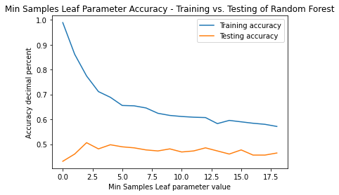

```python
best_accuracy = 0
best_min_samples = 0
train_accuracy = []
test_accuracy = []
x = [i for i in range(19)]

for i in range(1,20):
    clf = ensemble.RandomForestClassifier(min_samples_leaf=i)
    clf.fit(X_train, y_train)

    errors = sum([1 if clf.predict([u])[0] != v else 0 for u,v in zip(X_test,y_test)])
    accuracy = 1 - errors/len(test_data)
    if accuracy > best_accuracy:
        best_accuracy = accuracy
        best_min_samples = i

    errors = sum([1 if clf.predict([u])[0] != v else 0 for u,v in zip(X_train,y_train)])
    accuracy_train = 1 - errors/len(train_data)

    train_accuracy.append(accuracy_train)
    test_accuracy.append(accuracy)

fix, ax = plt.subplots()
ax.plot(x,train_accuracy)
ax.plot(x,test_accuracy)
ax.legend(["Training accuracy", "Testing accuracy"])
plt.title("Min Samples Leaf Parameter Accuracy - Training vs. Testing of Random Forest")
plt.xlabel("Min Samples Leaf parameter value")
plt.ylabel("Accuracy decimal percent")
plt.show()
```

```python
clf = ensemble.RandomForestClassifier(max_depth=best_depth, min_samples_leaf=best_min_samples)
clf.fit(X_train, y_train)

errors = sum([1 if clf.predict([u])[0] != v else 0 for u,v in zip(X_test,y_test)])
accuracy = 1 - errors/len(test_data)
accuracy
```

```
0.4979253112033195
```

### Max leaf nodes

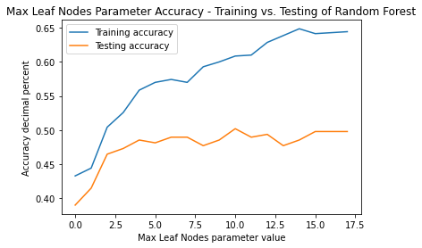

```python
best_accuracy = 0
best_leaf_node_max = 0
train_accuracy = []
test_accuracy = []
x = [i for i in range(18)]

for i in range(2,20):
    clf = ensemble.RandomForestClassifier(max_leaf_nodes=i)
    clf.fit(X_train, y_train)

    errors = sum([1 if clf.predict([u])[0] != v else 0 for u,v in zip(X_test,y_test)])
    accuracy = 1 - errors/len(test_data)
    if accuracy > best_accuracy:
        best_accuracy = accuracy
        best_leaf_node_max = i

    errors = sum([1 if clf.predict([u])[0] != v else 0 for u,v in zip(X_train,y_train)])
    accuracy_train = 1 - errors/len(train_data)

    train_accuracy.append(accuracy_train)
    test_accuracy.append(accuracy)

fix, ax = plt.subplots()
ax.plot(x,train_accuracy)
ax.plot(x,test_accuracy)
ax.legend(["Training accuracy", "Testing accuracy"])
plt.title("Max Leaf Nodes Parameter Accuracy - Training vs. Testing of Random Forest")
plt.xlabel("Max Leaf Nodes parameter value")
plt.ylabel("Accuracy decimal percent")
plt.show()
```

```python
clf = ensemble.RandomForestClassifier(min_samples_leaf=best_min_samples, max_depth=best_depth)
clf.fit(X_train, y_train)

errors = sum([1 if clf.predict([u])[0] != v else 0 for u,v in zip(X_test,y_test)])
accuracy = 1 - errors/len(test_data)
accuracy
```

```
0.4813278008298755
```

### Minimum weight fraction leaf

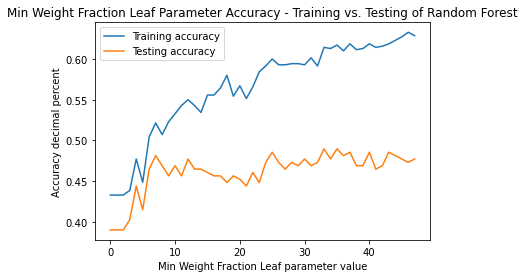

```python
best_accuracy = 0
best_min_weight = 0
train_accuracy = []
test_accuracy = []
x = [i for i in range(48)]

for i in range(2,50):
    clf = ensemble.RandomForestClassifier(min_weight_fraction_leaf=1/i)
    clf.fit(X_train, y_train)

    errors = sum([1 if clf.predict([u])[0] != v else 0 for u,v in zip(X_test,y_test)])
    accuracy = 1 - errors/len(test_data)
    if accuracy > best_accuracy:
        best_accuracy = accuracy
        best_min_weight = 1/i

    errors = sum([1 if clf.predict([u])[0] != v else 0 for u,v in zip(X_train,y_train)])
    accuracy_train = 1 - errors/len(train_data)

    train_accuracy.append(accuracy_train)
    test_accuracy.append(accuracy)

fix, ax = plt.subplots()
ax.plot(x,train_accuracy)
ax.plot(x,test_accuracy)
ax.legend(["Training accuracy", "Testing accuracy"])
plt.title("Min Weight Fraction Leaf Parameter Accuracy - Training vs. Testing of Random Forest")
plt.xlabel("Min Weight Fraction Leaf parameter value")
plt.ylabel("Accuracy decimal percent")
plt.show()
```

```python
clf = ensemble.RandomForestClassifier(min_samples_leaf=best_min_samples, max_depth=best_depth, min_weight_fraction_leaf=best_min_weight, max_leaf_nodes=best_leaf_node_max)
clf.fit(X_train, y_train)

errors = sum([1 if clf.predict([u])[0] != v else 0 for u,v in zip(X_test,y_test)])
accuracy = 1 - errors/len(test_data)
accuracy
```

```
0.46473029045643155
```

# What now?

So, our random forest model is not any better than our decision tree model— even after hyperparameter tuning. What are our options?

Well, one thing we can do is to include more features. The more information that our model has to predict from, the better (for the most part— we do lose some parsimony here which may induce overfitting). Another thing we can do is to include more training data. Unfortunately, Reddit limits webscrapers to the previous 1,000 posts, so we can't get much more training data in a reasonable time frame. Finally, we can decrease the number of classes to also potentially increase the accuracy of our classifier.

Ultimately, it's important to consider what a good accuracy is in this case. What if an accuracy of above 50% is already pretty good for the task at hand? For this, we would need a baseline.

## Defining a baseline in terms of accuracy

For our baseline, we will randomly predict a class for each sample in our testing data. From there, we will we will calculate the percent accuracy of that and use it as our baseline. Then, when doing accuracy calculations, we will define our new metric: $$P = \frac{A_{model} - A_{baseline}}{A_{baseline}}$$

```python
# Define intervals, then randomly sample from this list for each item in test data
intervals = ["<=3", "3-10", "10-50", ">50"]

test_baseline_classes = [''] * len(test_data)
for i in range(len(test_data)):
    test_baseline_classes[i] = random.sample(intervals, 1)[0]
```

```python
# Calculate the baseline accuracy
errors = sum([1 if u != v else 0 for u,v in zip(test_baseline_classes, y_test)])
baseline_accuracy = 1 - errors/len(test_data)
baseline_accuracy
```

```
0.24896265560165975
```

```python
# Calculate P metric for the Decision Tree Model
errors = sum([1 if final_decision_tree.predict([u])[0] != v else 0 for u,v in zip(X_test,y_test)])
accuracy = 1 - errors/len(test_data)

P_metric = (accuracy - baseline_accuracy)/baseline_accuracy
print("Our P_metric for the decision tree model is {}".format(P_metric))
```

```
Our P_metric for the decision tree model is 1.0
```

# P-metric interpretation

```python
print("Based on our obtained p-metric of {}, the model we obtained is outperforming the baseline by {}%!".format(P_metric, round(P_metric*100,2)))
```

```
Based on our obtained p-metric of 1.0, the model we obtained is outperforming the baseline by 100.0%!
```

Thus, relative to the baseline, our model is doing pretty well!

# Model deployment

Let's now use our model to predict the success of several posts! We'll do some informal testing of it on a hypothetical post, then move onto actual posts from a while ago and see how well it does!

## Example Post 1: A hypothetical post

```python
title = "What was your favorite CS 400-level course?"
description = "I'm currently making my schedule for next semester and I'm wondering if anyone has"\
                "any suggestions for CS 400-level courses to take? Thanks in advance!"
is_video = False
is_academic = True
is_athletics = False
is_discussion = False
is_events = False
is_help = False
is_housing = False
is_news = False
is_admissions = False
is_no_follow = False

final_decision_tree.predict([[len(title), len(description), is_video,is_academic,is_athletics,is_discussion,
                             is_events,is_help,is_housing,is_news,is_admissions,is_no_follow]])
```

```
array(['<=3'], dtype='<U5')
```

It looks like we might only get not get that many upvotes for this. If we are looking to post for the highest net upvotes, we might be better off doing something else!

## Example Post 2: A random post from 8 years ago

(This post received 6 net upvotes)

```python
title = "CS majors: 400 levels dilemma."
description = "So, I'm currently a rising senior and got two more semesters left since I'm trying to graduate in the four years. I think a few people are/have been in this situation. So for CS majors, we have to take a total of 7 400-level CS courses. I'm currently taking 2, and I need to take 5 more to complete my major requirements. This means I have to take 3 one semester, and 2 another semester. We are only allowed a maximum of 3 400-levels per semester anyway. My dilemma is whether or not I should just take 1 this summer, and then 2 for my remaining two semesters. So far, these 400 levels have taken quite a bit of time and effort, so it's not a breeze in the park for me. I know for sure I will struggle if I take 3, but not necessarily fail. I would just have to put in a lot of effort. This is also assuming I can even get all the 400-levels that I actually want to take. I'm considering the summer option, but I'm not sure if paying $1300 is worth it. It's a pretty big chunk of money. I don't have a job or internship right now, and my parents have already been paying so much for both me and brother's college, so I would feel bad asking them. So, should I just go ahead and pay $1300 for the summer, or should I suck it up and attempt to do 3 400-levels? Or other options/advice? Thanks! Side Question: Is ENGL393 beneficial/worth it to me as a CS major, or should I take another one of the 39X classes that I may find more interesting? Thanks!"
is_video = False
is_academic = True
is_athletics = False
is_discussion = False
is_events = False
is_help = False
is_housing = False
is_news = False
is_admissions = False
is_no_follow = False

final_decision_tree.predict([[len(title), len(description), is_video,is_academic,is_athletics,is_discussion,
                             is_events,is_help,is_housing,is_news,is_admissions,is_no_follow]])
```

```
array(['<=3'], dtype='<U5')
```

## Example Post 3: The most upvoted post on the entire subreddit

This one will likely be harder for the model since it is a video and it doesn't look like there are many videos in the training data set

(This post received 1327 net upvotes)

```python
title = "For Karate KNES144Q, we have to record ourselves practicing kicks. I accidentally kicked my chair."
description = ""
is_video = True
is_academic = False
is_athletics = False
is_discussion = False
is_events = False
is_help = False
is_housing = False
is_news = False
is_admissions = False
is_no_follow = False

final_decision_tree.predict([[len(title), len(description), is_video,is_academic,is_athletics,is_discussion,
                             is_events,is_help,is_housing,is_news,is_admissions,is_no_follow]])
```

```
array(['>50'], dtype='<U5')
```

## Example Post 4: The second most upvoted post on the entire subreddit

(This post received 957 net upvotes)

```python
title = "UMD Under a Thunderstorm ⛈⚡️"
description = ""
is_video = False
is_academic = False
is_athletics = False
is_discussion = True
is_events = False
is_help = False
is_housing = False
is_news = False
is_admissions = False
is_no_follow = False

final_decision_tree.predict([[len(title), len(description), is_video,is_academic,is_athletics,is_discussion,
                             is_events,is_help,is_housing,is_news,is_admissions,is_no_follow]])
```

```
array(['>50'], dtype='<U5')
```

It looks like our model predicted this one correctly!

## Example Post 5: A popular post on Fraternities

(This post received 742 net upvotes)

```python
title = "Fraternity member here: we ARE the problem"
description = "I'm hoping that people do not read the title of this post and downvote it immediately, because I am trying to have a real discussion here. Fraternities may not be the only group responsible from spreading the COVID-19 virus, but they are definitely a big part of it. Here are a few reasons.First, in-person rush events. I guarantee that every mid to top tier fraternity on campus has had at least some of these, since otherwise they would not get a big enough pledge class. It's been a well, since they're doing it, I guess we should do it kind of thing. This is bad because it is basically turning these poor freshmen into super-spreaders. They rush around 3 or 4 different frats, and if they have COVID, they will just spread it everywhere. Plus, they will bring it back to their dorm, and likely spread it to people there as well.Second, lack of compliance with the University. Every single brother that I've talked to has failed to keep up with the bi-weekly testing policy. Excuses that I've heard are but I'm only hanging out with people from the house or the University testing center is 100% booked for this week. If you want to get tested, it is not difficult. I got one at the Urgent Care across from the Varsity, and it only took me like 20 minutes. The bottom line is that the University is not punishing anyone for breaking the rules that they set. I want them to, and I do not care if they specifically go out of their way to specifically punish members of Greek Life. It would be one of the absolute best things that they can do to limit the spread of Coronavirus.Third, full on socials. While my fraternity has not had any real socials this semester, I know that a solid 25% of them have. And I'm not talking small get togethers, I'm talking >100 people in a sweaty basement without masks. Plus, since a good10-20% of each chapter is made up of off-campus students, there is no shot that they've been getting regularly tested. On top of this, some groups have literally been caught by police. This is supposed to come with a $5000 fine as well as probation from IFC. That sure as hell has not been happening, but it definitely needs to.Now, I want to pre-emptively answer some of the things that people may be thinking.Why did you post this?I really don't know if there are any other fraternity members in this subreddit, since it seems like Reddit is generally pretty anti-frat. But if there are, I want you guys to start taking some responsibility for what is going on here. Anybody that tells you that we are just the University's scapegoats is lying to their self. If you are not a part of a Greek organization, but you know people that are, feel free to show them this post or talk to them. It may be difficult, and they may get extremely defensive, but I've found that the most difficult conversations are often the most important.2) Why are you even in a fraternity? Greek Life deserves to be completely abolishedFirst, I think that Greek Life has a lot of benefits. As an introvert, it has really brought me out of my shell (testudo pun not intended) and improved the social aspect of my life. It has also been a great networking tool for me, and was the reason I landed an Internship for the upcoming summer. However, I acknowledge that there are major problems. Racism, sexism, homophobia, ableism, and hazing within fraternities are not myths. While there have been MAJOR improvements in recent years, it will still take a tremendous amount of work to completely remove these things from fraternity culture. I genuinely believe that we are moving in the right direction, and one of the reasons that I joined was to be a positive influence in that movement. However, if I'm wrong and these things will never change, then yeah, abolish Greek Life.3) What the hell bro, it's like totally not frat of you to post this. You're, like, putting our brotherhood at risk dude Good"
is_video = False
is_academic = False
is_athletics = False
is_discussion = True
is_events = False
is_help = False
is_housing = False
is_news = False
is_admissions = False
is_no_follow = False

final_decision_tree.predict([[len(title), len(description), is_video,is_academic,is_athletics,is_discussion,
                             is_events,is_help,is_housing,is_news,is_admissions,is_no_follow]])
```

```
array(['3-10'], dtype='<U5')
```

## Example Post 6: A post with zero net upvotes

```python
title = "What were your stats transferring in to UMD? And what are my chances?"
description = "Currently at a community college in Virginia, so out of state. I will have 35 credits and above a 3.3 GPA when attempting to transfer for the fall.I also have a job and work for the largest newspaper in the state."
is_video = False
is_academic = True
is_athletics = False
is_discussion = True
is_events = False
is_help = False
is_housing = False
is_news = False
is_admissions = False
is_no_follow = True

final_decision_tree.predict([[len(title), len(description), is_video,is_academic,is_athletics,is_discussion,
                             is_events,is_help,is_housing,is_news,is_admissions,is_no_follow]])
```

```
array(['<=3'], dtype='<U5')
```

# Performance Evalutation and Conclusion

So, our model seems to be performing alright in practice. While there are some errors, it is much better than the baseline.

What can we conclude?

Well, training this model might be a good way to guage how well a certain post will be received by r/UMD but it is not exactly proof of how well it will do. Future work would involve gaining a larger data set and introducing more features to train the model.

That said, I encourage anyone looking to make a post on r/UMD to use this model as a (quite rough) estimate of the the popularity of their post!